# Exploring Carabid Beetle and Spider Diversity, Community Composition and Functional Traits Across Vineyard and Semi-Natural Habitats

#### 7.1.1 Meeting model assumptions

Checking for collinearity Model diagnostics and performance

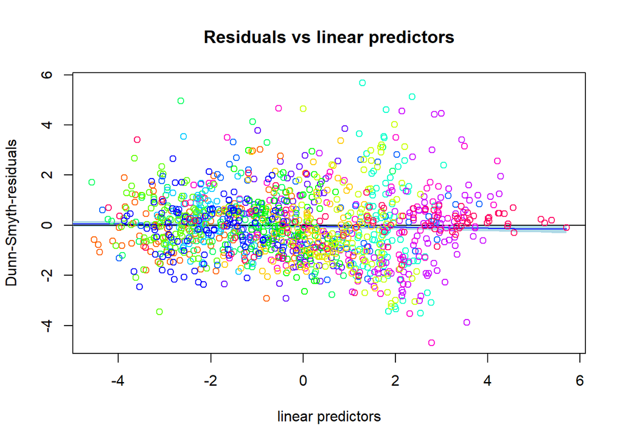

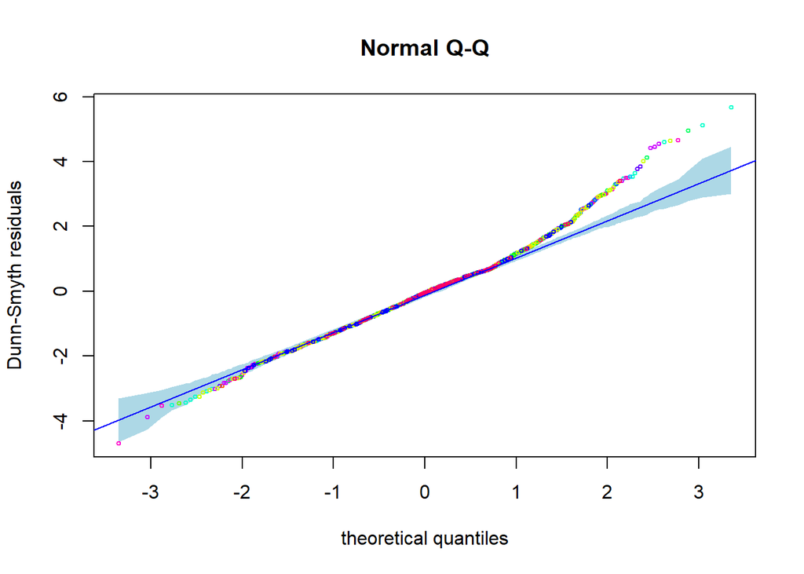

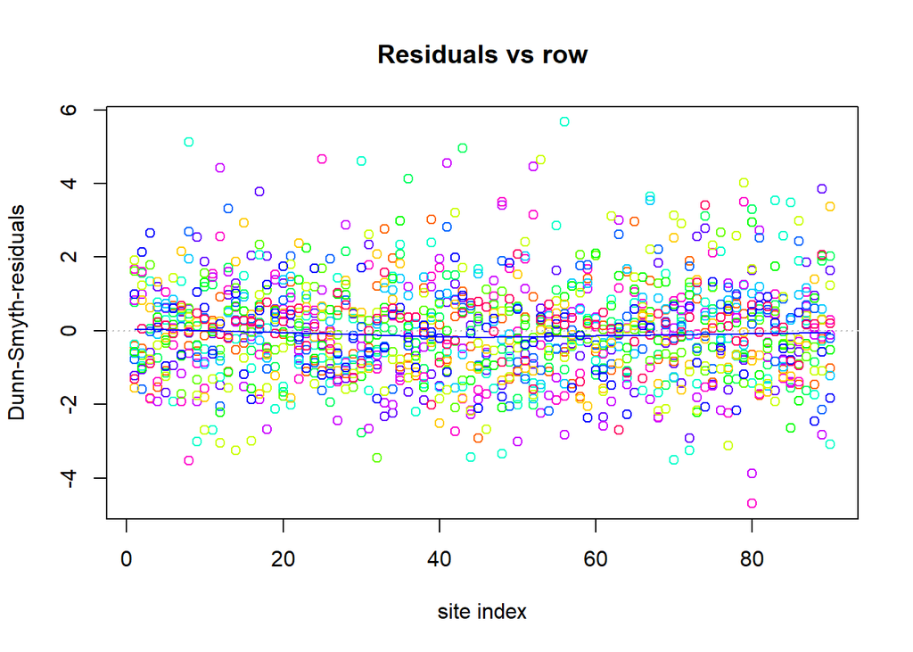

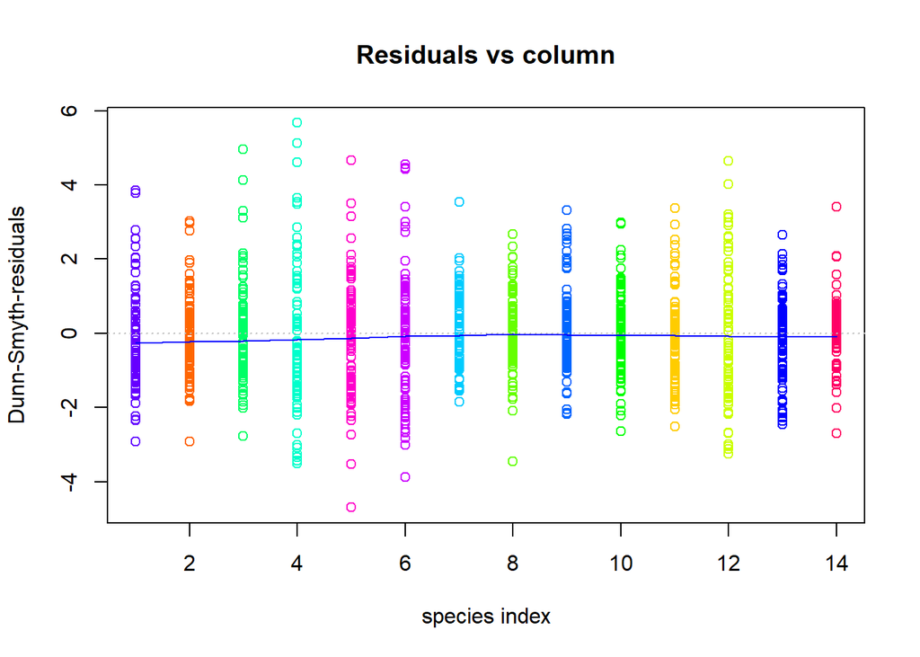

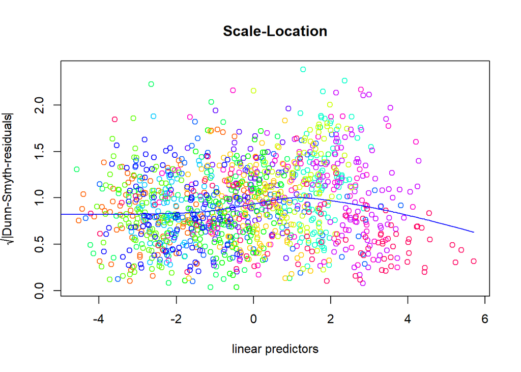

```r
# biplot of the GLLVM
plot(gllvm_spider_pois, biplot = TRUE, ind.spp = TRUE)
```

Residuals are fan shaped, indicating overdispersion. let’s try a negative binomial distribution.

```r
# Fit GLLVM using factors (without continuous covariates)
# rare families (<5) removed
gllvm_spider_nb <- gllvm(
  y = Y_spider_rare_removed,
  X = X_spider,
  family = "negative.binomial",
  formula = ~ habitat + year,
  num.lv = 2,
  studyDesign = studyDesign,
  row.eff = ~(1 | site_ID),
  offset = off_vec,
  method = "VA"
)

summary(gllvm_spider_nb)
```

```
##
## Call:
## gllvm(y = Y_spider_rare_removed, X = X_spider, formula = ~habitat +
##     year, family = "negative.binomial", num.lv = 2, studyDesign = studyDesign,
##     row.eff = ~(1 | site_ID), offset = off_vec, method = "VA")
##
## Family:  negative.binomial
##
## AIC:  4452.639 AICc:  4464.792 BIC:  4884.304 LL:  -2142.3 df:  84
##
## Informed LVs:  0
## Constrained LVs:  0
## Unconstrained LVs:  2
##
## Formula:  ~habitat + year
## LV formula:  ~1
## Row effect:  ~(1 | site_ID)
##
## Coefficients predictors:
##                            Estimate Std. Error z value Pr(>|z|)
## habitatVY:AGELENIDAE     -7.954e-01  3.260e-01  -2.440 0.014704 *
## habitatVY:CORINNIDAE     -2.138e+00  8.882e-01  -2.407 0.016093 *
## habitatVY:DICTYNIDAE      1.277e+00  7.696e-01   1.660 0.096980 .
## habitatVY:GNAPHOSIDAE     3.569e-01  1.774e-01   2.012 0.044206 *
## habitatVY:LINYPHIIDAE     2.592e+00  2.822e-01   9.184  < 2e-16 ***
## habitatVY:LYCOSIDAE       1.439e-01  1.938e-01   0.742 0.457790
## habitatVY:PHILODROMIDAE   4.437e-01  8.930e-01   0.497 0.619261
## habitatVY:PHOLCIDAE      -3.328e-01  8.199e-01  -0.406 0.684832
## habitatVY:PHRUROLITHIDAE -2.594e+00  4.193e-01  -6.186 6.18e-10 ***
## habitatVY:SALTICIDAE     -4.196e-01  3.095e-01  -1.356 0.175222
## habitatVY:THERIDIIDAE    -4.524e-01  2.734e-01  -1.655 0.097990 .
## habitatVY:THOMISIDAE      5.082e-03  2.162e-01   0.024 0.981246
## habitatVY:TITANOECIDAE   -1.511e+00  6.763e-01  -2.234 0.025479 *
## habitatVY:ZODARIIDAE      7.314e-01  3.602e-01   2.030 0.042309 *
## year2025:AGELENIDAE       1.046e+00  3.934e-01   2.659 0.007841 **
## year2025:CORINNIDAE      -1.656e+00  7.805e-01  -2.122 0.033830 *
## year2025:DICTYNIDAE       1.487e+00  8.450e-01   1.760 0.078396 .
## year2025:GNAPHOSIDAE     -9.928e-02  1.917e-01  -0.518 0.604556
## year2025:LINYPHIIDAE      6.660e-01  2.966e-01   2.245 0.024755 *
## year2025:LYCOSIDAE        1.229e-01  2.106e-01   0.584 0.559472
## year2025:PHILODROMIDAE    1.403e+01  5.914e+02   0.024 0.981066
## year2025:PHOLCIDAE       -4.702e-01  8.276e-01  -0.568 0.569940
## year2025:PHRUROLITHIDAE   1.594e+00  4.544e-01   3.508 0.000452 ***
## year2025:SALTICIDAE       7.720e-01  3.790e-01   2.037 0.041682 *
## year2025:THERIDIIDAE      1.138e+00  3.468e-01   3.282 0.001032 **
## year2025:THOMISIDAE       1.036e+00  2.541e-01   4.079 4.53e-05 ***
## year2025:TITANOECIDAE     5.978e-04  6.051e-01   0.001 0.999212
## year2025:ZODARIIDAE       5.378e-01  3.967e-01   1.356 0.175250
## ---
## Signif. codes:  0 '***' 0.001 '**' 0.01 '*' 0.05 '.' 0.1 ' ' 1
```

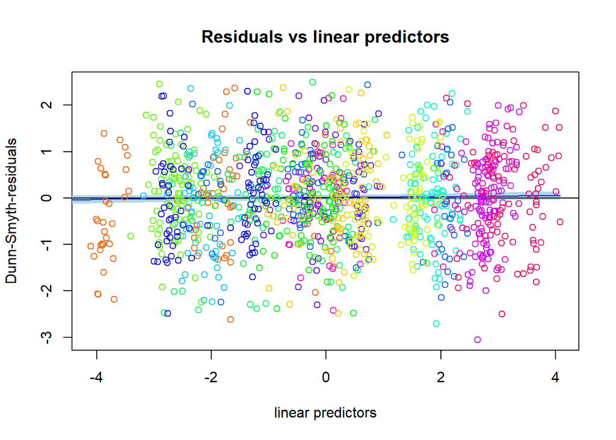

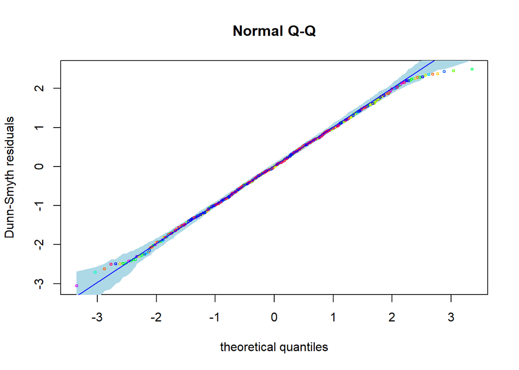

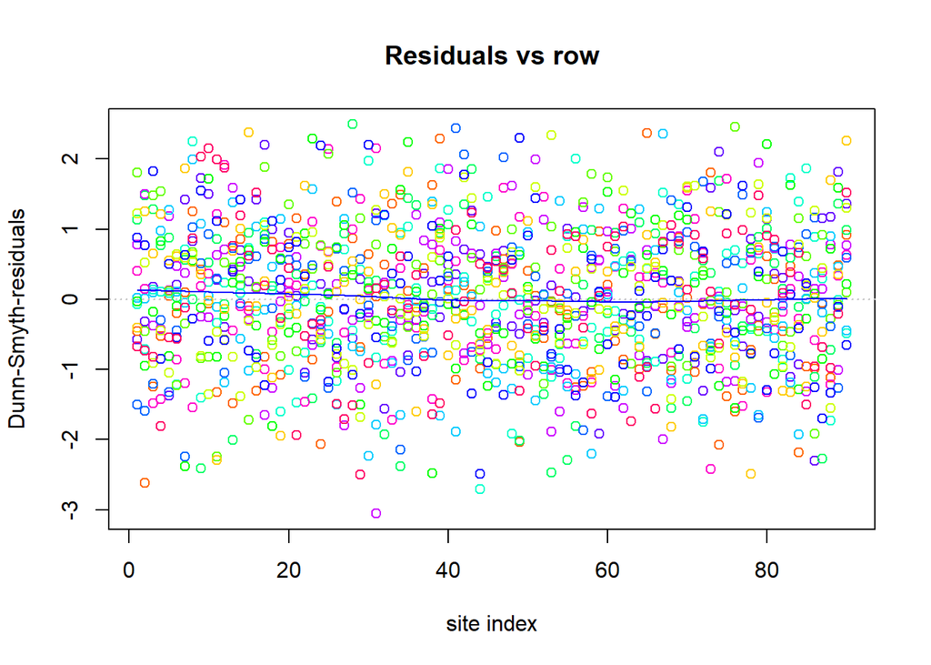

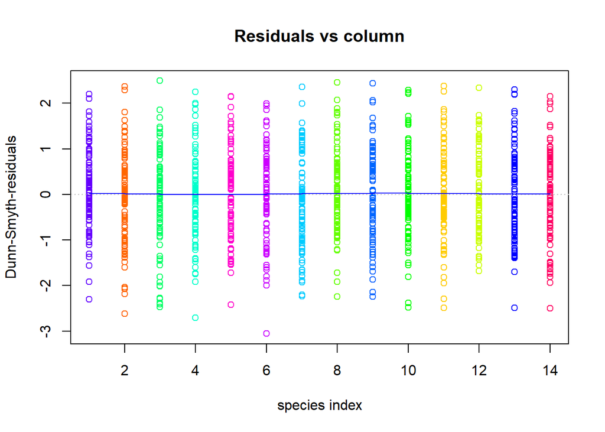

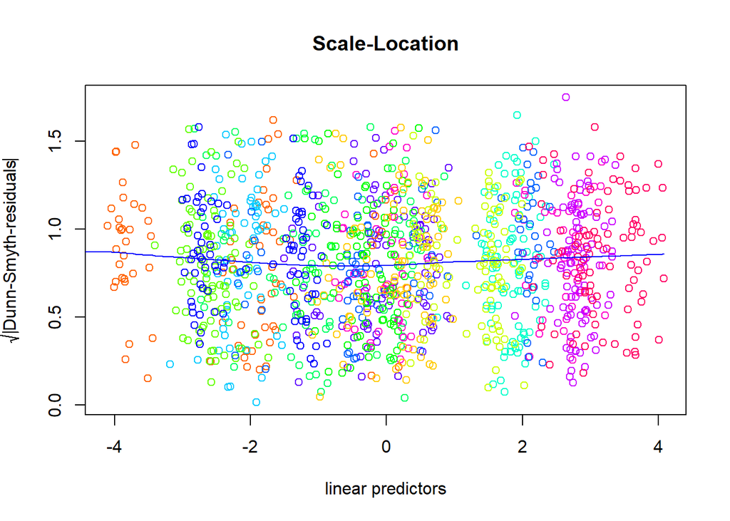

```r
# biplot of the GLLVM
plot(gllvm_spider_nb, biplot = TRUE, ind.spp = TRUE)
```

Residuals look better and AICc is smaller for NB model

#### 7.1.2 Model outputs

Let’s plot the gllvm model coefficients

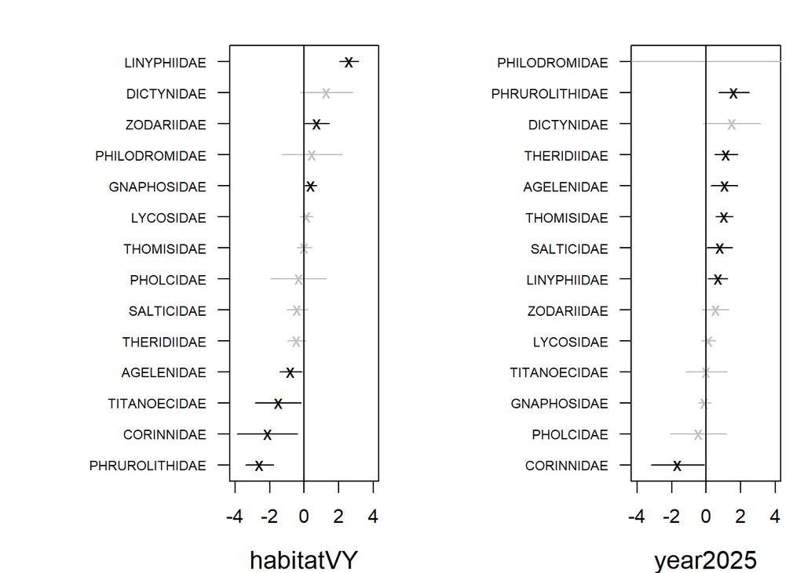

```r
# plot the gllvm spider coefficient plot
coefplot(
  gllvm_spider_nb,
  cex.ylab = 0.7,
  mar = c(4, 10, 2, 1),
  xlim.list = list(
    c(-4, 4),   # habitat
    c(-4, 4)    # year
  )
)
```

Let’s clean up the axis and save the gllvm model coefficient plot

```r
# Convert family names to sentence case
gllvm_spider_nb_sc <- gllvm_spider_nb
spider_families <- stringr::str_to_sentence(
  rownames(gllvm_spider_nb_sc$params$Xcoef)
)

rownames(gllvm_spider_nb_sc$params$Xcoef) <- spider_families
rownames(gllvm_spider_nb_sc$sd$Xcoef)     <- spider_families

# open device to save plot using base R
png(
  filename = here::here("03_figures", "spider_gllvm_plot.png"),
  width = 7,
  height = 5,
  units = "in",
  res = 400
)

# plot the gllvm spider coefficient plot
coefplot(
  gllvm_spider_nb_sc,
  cex.ylab = 0.7,
  mar = c(4, 10, 2, 1),
  xlim.list = list(
    c(-4, 4),   # habitat
    c(-4, 4)    # year
  )
)

# close device
dev.off()
```

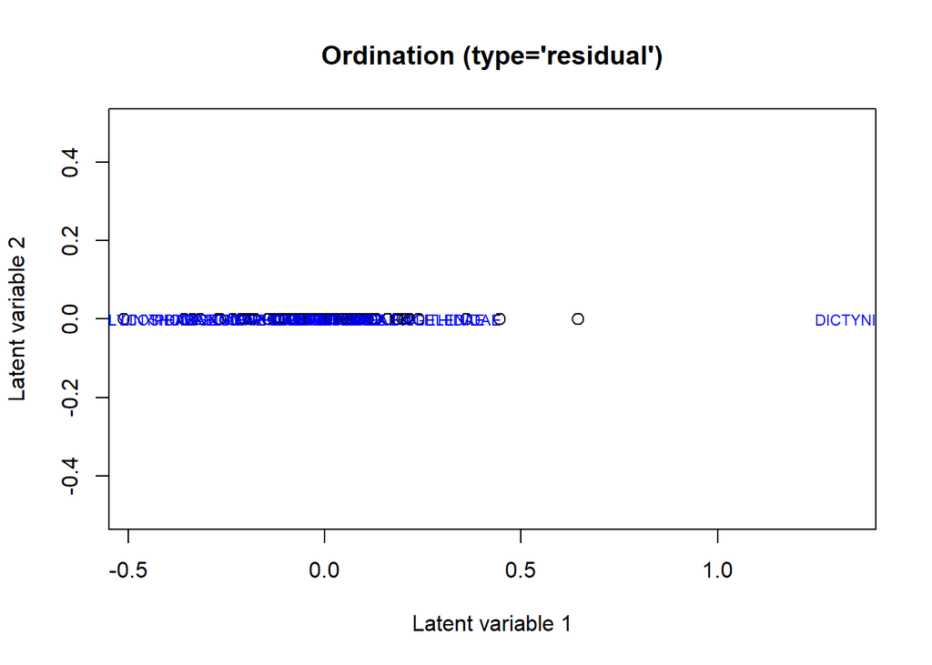

```r
# let's also look at the ordination plot, with latent variables as axis
ordiplot(gllvm_spider_nb,
         biplot  = TRUE,
         ind.spp = 16,
         symbols = TRUE)
```

### 7.2 Spider Fourth Corner Model

First we’ll prepare the traits dataset

```r
# FAMILY TRAITS
# Ensure the species names in traits match the columns in Y
spider_traits_rare_removed <- spider_traits %>% filter(spider_family %in% colnames(Y_spider_rare_removed))

# ensure it's a dataframe in the same order as Y
spider_traits_ordered <- spider_traits_rare_removed[match(colnames(Y_spider_rare_removed), spider_traits_rare_removed$spider_family), ]


# make spider_family the row names
rownames(spider_traits_ordered) <- spider_traits_ordered$spider_family

# keep only the guild code column
TR_spider <- spider_traits_ordered %>%
  dplyr::select(guild_code)

# Make sure it matches!
all(colnames(Y_spider_rare_removed) %in% rownames(TR_spider))
```

```
## [1] TRUE
```

```r
sum(colnames(Y_spider_rare_removed) %in% rownames(TR_spider))
```

```
## [1] 14
```

```r
# make sure reference levels make sense for model
X_spider$habitat <- relevel(factor(X_spider$habitat), ref = "SNH")

# set dispersal power reference level to macropterous
TR_spider$guild_code <- relevel(
  factor(TR_spider$guild_code),
  ref = "GRH"
)
```

```r
# run gllvm fourth corner model with spider traits
# still include site_ID as a row effect and offset
gllvm_spider_traits <- gllvm(
  y = Y_spider_rare_removed,
  X = as.data.frame(X_spider),
  TR = TR_spider,
  family = "negative.binomial",
  num.lv = 2,
  method = "VA",
  offset = off_vec,
  studyDesign = studyDesign,
  row.eff = ~(1 | site_ID),
  formula = y ~ habitat * (guild_code))

summary(gllvm_spider_traits)
```

```
##
## Call:
## gllvm(y = Y_spider_rare_removed, X = as.data.frame(X_spider),
##     TR = TR_spider, formula = y ~ habitat * (guild_code), family = "negative.binomial",
##     num.lv = 2, studyDesign = studyDesign, row.eff = ~(1 | site_ID),
##     offset = off_vec, method = "VA")
##
## Family:  negative.binomial
##
## AIC:  4525.378 AICc:  4533.984 BIC:  4890.237 LL:  -2191.7 df:  71
##
## Informed LVs:  0
## Constrained LVs:  0
## Unconstrained LVs:  2
##
## Formula:  ~habitatVY+guild_codeAMH+guild_codeOTH+guild_codeSHW+guild_codeSHW/ OTH+guild_codeSPE+guild_codeSPW+guild_codeSPW/ GRH+habitatVY:guild_codeAMH+habitatVY:guild_codeOTH+habitatVY:guild_codeSHW+habitatVY:guild_codeSHW/ OTH+habitatVY:guild_codeSPE+habitatVY:guild_codeSPW+habitatVY:guild_cod…
## LV formula:  ~ 0
## Row effect:  ~(1 | site_ID)
##
## Coefficients predictors:
##                              Estimate Std. Error z value Pr(>|z|)
## habitatVY                     0.08840    0.13628   0.649  0.51654
## guild_codeAMH                -0.19953    0.08846  -2.256  0.02410 *
## guild_codeOTH                -1.94600    0.10299 -18.896  < 2e-16 ***
## guild_codeSHW                -0.67606    0.11192  -6.041 1.53e-09 ***
## guild_codeSHW/ OTH           -0.89885    0.12015  -7.481 7.37e-14 ***
## guild_codeSPE                 0.44580    0.14996   2.973  0.00295 **
## guild_codeSPW                -2.08143    0.08421 -24.717  < 2e-16 ***
## guild_codeSPW/ GRH           -1.51436    0.32262  -4.694 2.68e-06 ***
## habitatVY:guild_codeAMH      -0.04095    0.27550  -0.149  0.88183
## habitatVY:guild_codeOTH      -0.45869    0.32868  -1.396  0.16285
## habitatVY:guild_codeSHW      -0.84317    0.35894  -2.349  0.01882 *
## habitatVY:guild_codeSHW/ OTH  2.59791    0.32287   8.046 8.54e-16 ***
## habitatVY:guild_codeSPE       0.82938    0.41736   1.987  0.04690 *
## habitatVY:guild_codeSPW      -0.78495    0.28462  -2.758  0.00582 **
## habitatVY:guild_codeSPW/ GRH  1.30423    0.87756   1.486  0.13723
## ---
## Signif. codes:  0 '***' 0.001 '**' 0.01 '*' 0.05 '.' 0.1 ' ' 1
```

#### 7.2.1 Meeting model assumptions

Checking for collinearity Model diagnostics and performance

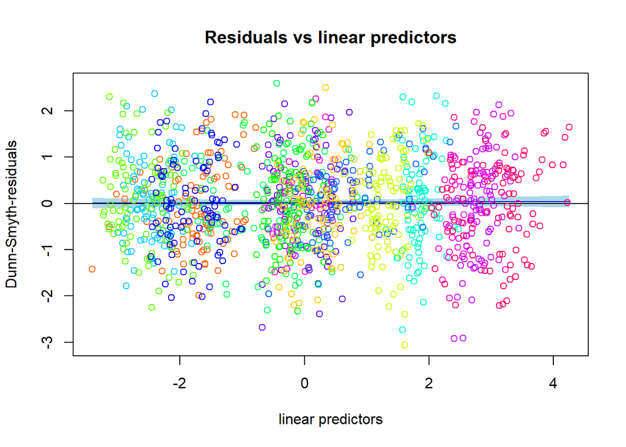

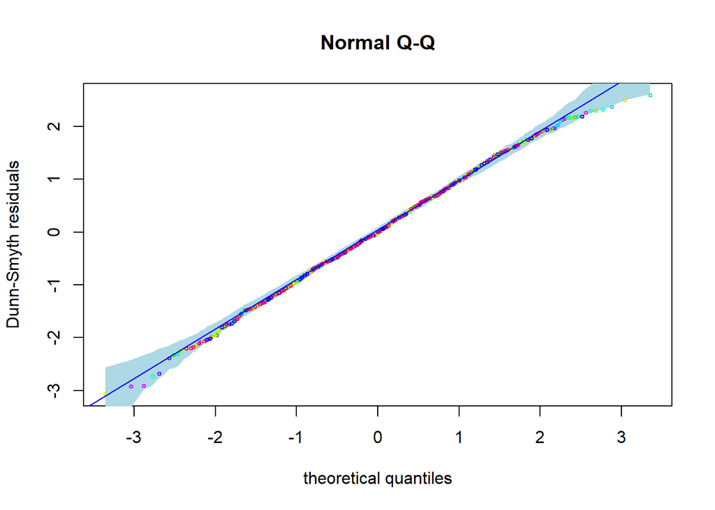

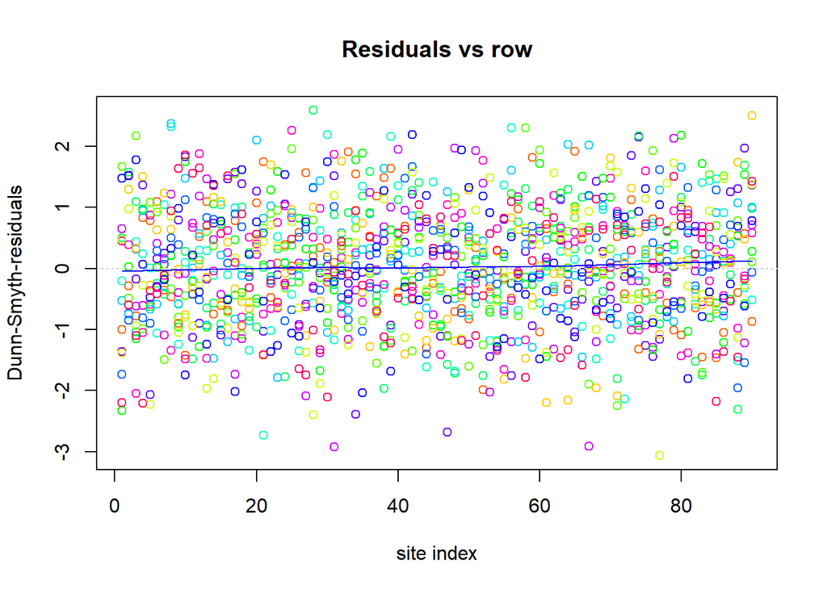

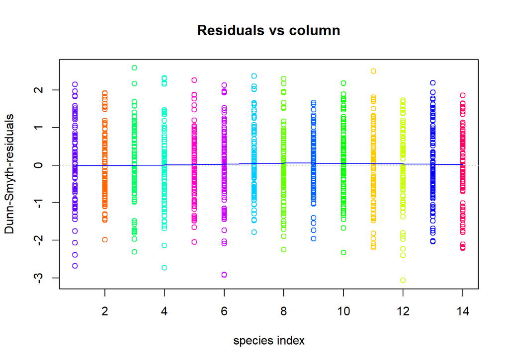

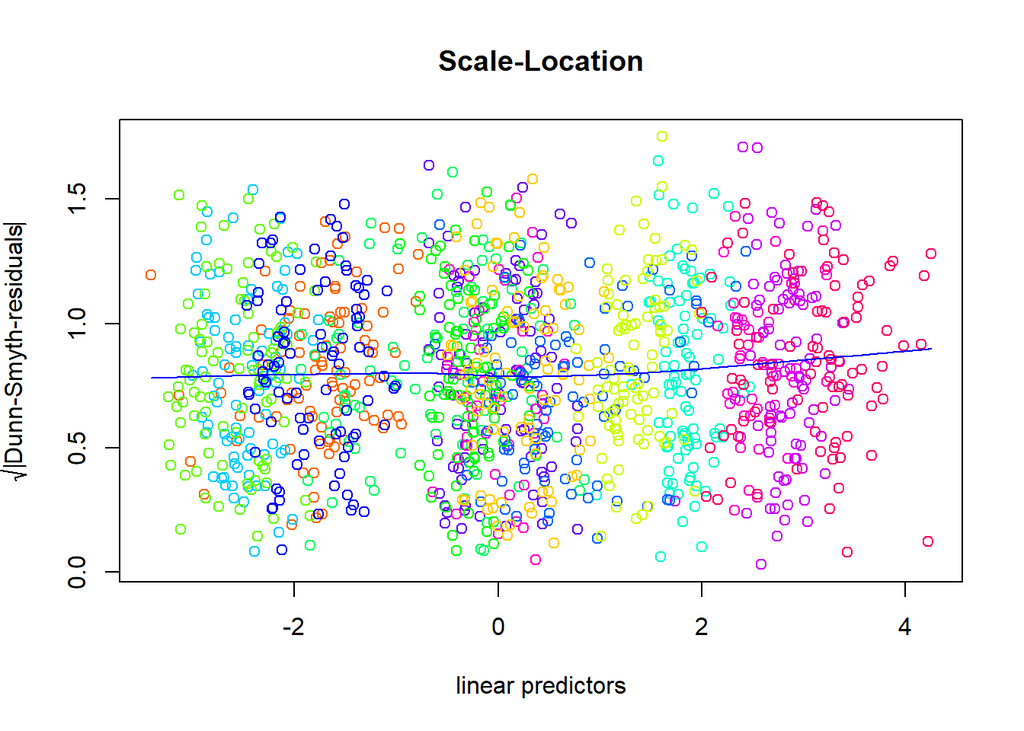

```r
# biplot of the GLLVM
plot(gllvm_spider_traits, biplot = TRUE, ind.spp = TRUE)
```

residuals look okay!

#### 7.2.2 Model outputs

Let’s make a plot for the coefficients from 4th corner model

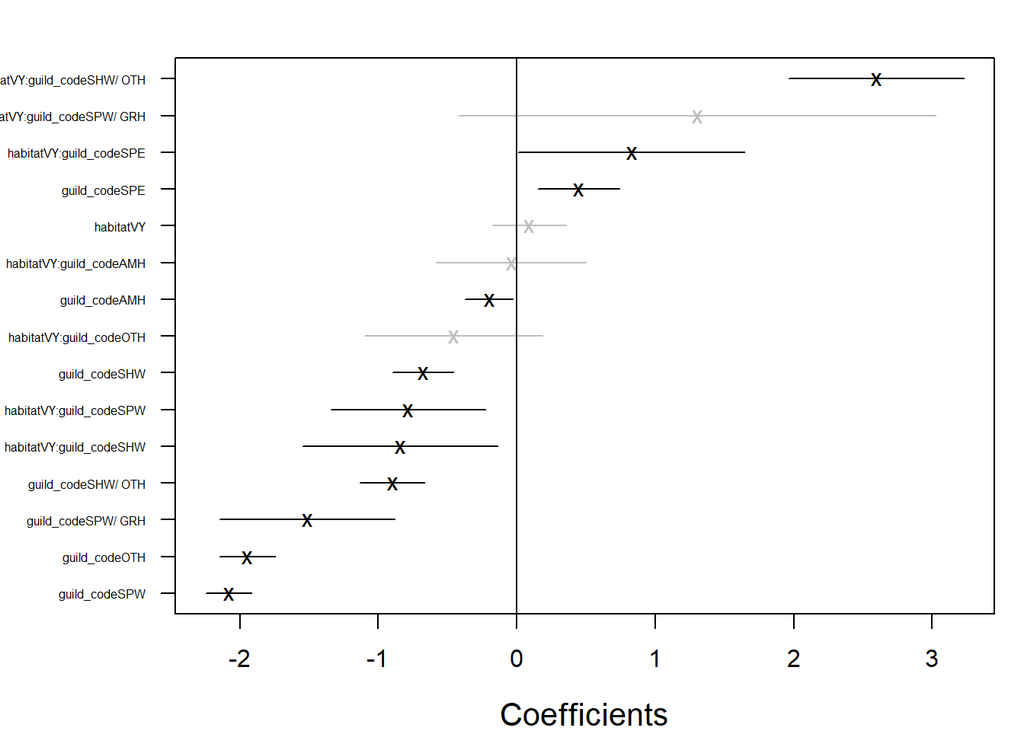

```r
coefplot(gllvm_spider_traits)
```

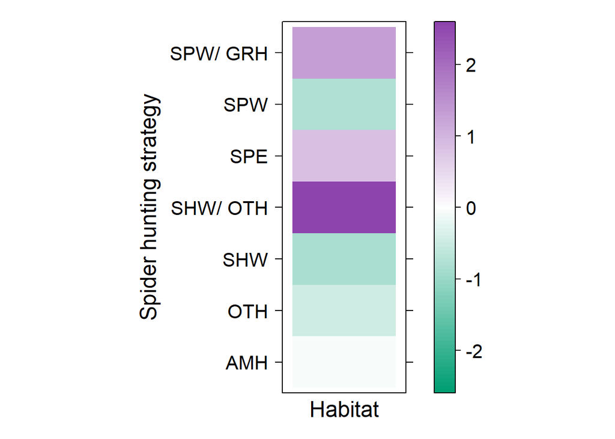

```r
spider_fourth <- gllvm_spider_traits$fourth.corner
a <- max( abs(spider_fourth) )


# remove guild_code for plotting
colnames(spider_fourth) <- colnames(spider_fourth) |>
  str_remove("^guild_code_?") |>   # remove prefix
  str_replace("_", " / ")          # optional: make combinations readable


# custom colors (gradient based on VY/ SNH colors)
colort <- colorRampPalette(c(
  custom_colors["SNH"],  # negative
  "white",
  custom_colors["VY"]    # positive
))

# plot use level plot from lattice package
spider_4th_plot <- levelplot(
  as.matrix(spider_fourth),
  xlab = "Habitat",
  ylab = "Spider hunting strategy",
  col.regions = colort(100),
  cex.lab = 1.3,
  at = seq(-a, a, length = 100),
  scales = list(x = list(draw = FALSE)),
  par.settings = list(
    axis.text = list(cex = 1.3),
    par.xlab.text = list(cex = 1.5),
    par.ylab.text = list(cex = 1.5),
    par.legend.text = list(cex = 1.3)
  )
)

spider_4th_plot
```

```r
# open device (save image using base R, lattice not compatible with ggsave)
png(
  filename = here::here("03_figures", "spider_4th_plot.png"),
  width = 7,
  height = 7,
  units = "in",
  res = 400
)

# draw the plot
print(spider_4th_plot)

# close device
dev.off()
```

Relative to SNH, VY support more SHW/ OTH

### 7.3 Carabid GLLVM

First we’ll prepare the data and get it in the right format for GLLVM modelling

```r
# Offset (log effort) and final response matrix
effort_vec <- pmax(carabid_habitat_summary$trap_count, 1L)   # guard against 0
off_vec    <- log(effort_vec)

# --- site_ID: grouping factor for random site intercept -------------------
# one site label per sample row (should be length 90)
site_ID <- carabid_habitat_summary %>%
  dplyr::select(site_ID) %>%
  mutate(across(everything(), as.factor))


Y_carabid <- carabid_habitat_summary %>%
  dplyr::select(all_of(species_columns)) %>%
  as.matrix()

# Covariate matrix (habitat and season only)
X_carabid <- carabid_habitat_summary %>%
  dplyr::select(site_ID, habitat, year) %>%
  mutate(across(everything(), as.factor))

# --- Identify rare species to exclude -------------------------------------
species_occurrence_summary <- carabid_habitat_summary %>%
  summarise(across(all_of(species_columns), ~ sum(. > 0))) %>%
  pivot_longer(cols = everything(), names_to = "species", values_to = "n_samples")

# Threshold: must occur in at least 5 unique samples
species_to_keep <- species_occurrence_summary %>%
  filter(n_samples > 5) %>%
  pull(species)

# --- Filter Y to include only common species ------------------------------
Y_rare_carabid_removed <- carabid_habitat_summary %>%
  dplyr::select(all_of(species_to_keep)) %>%
  as.matrix()
```

Next we’ll run the gllvm model (with poisson distribution to start)

```r
# Fit GLLVM using factors
# rare species (<5) removed
# habitat as predictors (without continuous covariates)
# include 2 latent variables and offset
gllvm_carabid_pois <- gllvm(
  y = Y_rare_carabid_removed,
  X = X_carabid,
  family = "poisson",
  formula = ~ habitat + year,
  num.lv = 2,
  studyDesign = studyDesign,
  row.eff = ~(1 | site_ID),
  offset = off_vec,
  method = "VA"
)


summary(gllvm_carabid_pois)
```

```
##
## Call:
## gllvm(y = Y_rare_carabid_removed, X = X_carabid, formula = ~habitat +
##     year, family = "poisson", num.lv = 2, studyDesign = studyDesign,
##     row.eff = ~(1 | site_ID), offset = off_vec, method = "VA")
##
## Family:  poisson
##
## AIC:  2142.758 AICc:  2151.706 BIC:  2533.347 LL:  -996.4 df:  75
##
## Informed LVs:  0
## Constrained LVs:  0
## Unconstrained LVs:  2
##
## Formula:  ~habitat + year
## LV formula:  ~1
## Row effect:  ~(1 | site_ID)
##
## Coefficients predictors:
##                                   Estimate Std. Error z value Pr(>|z|)
## habitatVY:Agonoleptus_conjunctus   -0.1218     0.8574  -0.142 0.886995
## habitatVY:Amara_aenea               1.8857     0.6019   3.133 0.001732 **
## habitatVY:Amara_apricaria           2.6547     1.3231   2.006 0.044807 *
## habitatVY:Amara_quenseli           -1.1115     0.7318  -1.519 0.128826
## habitatVY:Anisodactylus_binotatus  -0.3148     1.0689  -0.294 0.768400
## habitatVY:Calathus_fuscipes         1.8052     0.7787   2.318 0.020438 *
## habitatVY:Calosoma_tepidum          3.7841     1.1110   3.406 0.000659 ***
## habitatVY:Carabus_nemoralis         2.1880     1.0928   2.002 0.045262 *
## habitatVY:Carabus_taedatus         -4.2619     1.8711  -2.278 0.022741 *
## habitatVY:Harpalus_affinis          2.1864     0.2523   8.667  < 2e-16 ***
## habitatVY:Harpalus_fraternus        1.4642     0.4685   3.125 0.001777 **
## habitatVY:Harpalus_herbivagus       2.2540     0.7792   2.893 0.003819 **
## habitatVY:Harpalus_opacipennis      1.4368     1.4275   1.007 0.314166
## habitatVY:Harpalus_pensylvanicus   24.7204     0.3878  63.743  < 2e-16 ***
## habitatVY:Pterostichus_melanarius   1.7933     0.7237   2.478 0.013208 *
## year2025:Agonoleptus_conjunctus    -0.5495     0.8589  -0.640 0.522306
## year2025:Amara_aenea               -0.0882     0.4862  -0.181 0.856052
## year2025:Amara_apricaria           -0.5316     1.1027  -0.482 0.629767
## year2025:Amara_quenseli            30.4793     0.3303  92.272  < 2e-16 ***
## year2025:Anisodactylus_binotatus    1.9350     1.4546   1.330 0.183445
## year2025:Calathus_fuscipes          1.7157     0.8538   2.009 0.044496 *
## year2025:Calosoma_tepidum          -0.1126     0.6161  -0.183 0.855023
## year2025:Carabus_nemoralis         23.4231     0.5366  43.654  < 2e-16 ***
## year2025:Carabus_taedatus           1.0567     1.7725   0.596 0.551082
## year2025:Harpalus_affinis           0.3326     0.2406   1.382 0.166884
## year2025:Harpalus_fraternus        -0.1982     0.4499  -0.441 0.659468
## year2025:Harpalus_herbivagus        1.4870     0.6795   2.189 0.028629 *
## year2025:Harpalus_opacipennis      -1.1799     1.3774  -0.857 0.391633
## year2025:Harpalus_pensylvanicus     0.8462     0.8062   1.050 0.293878
## year2025:Pterostichus_melanarius    0.7002     0.7951   0.881 0.378520
## ---
## Signif. codes:  0 '***' 0.001 '**' 0.01 '*' 0.05 '.' 0.1 ' ' 1
```

#### 7.3.1 Meeting model assumptions

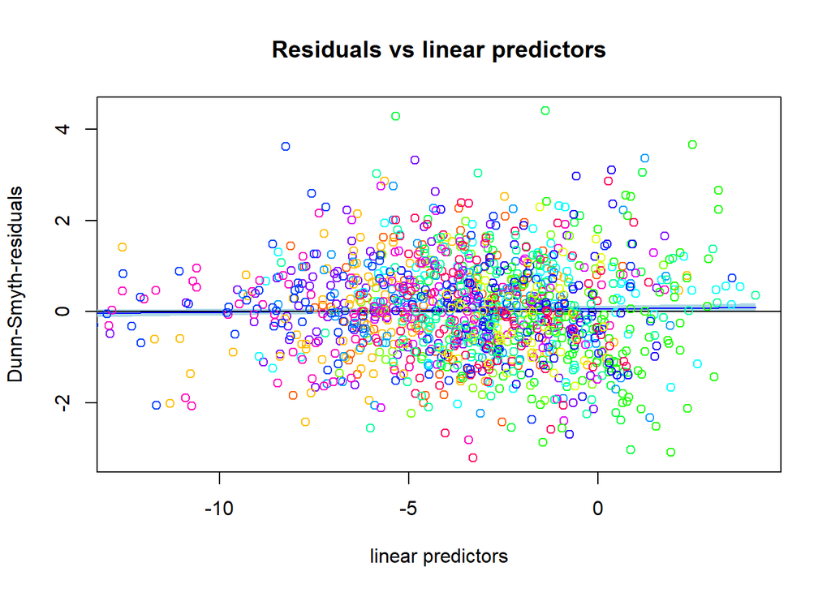

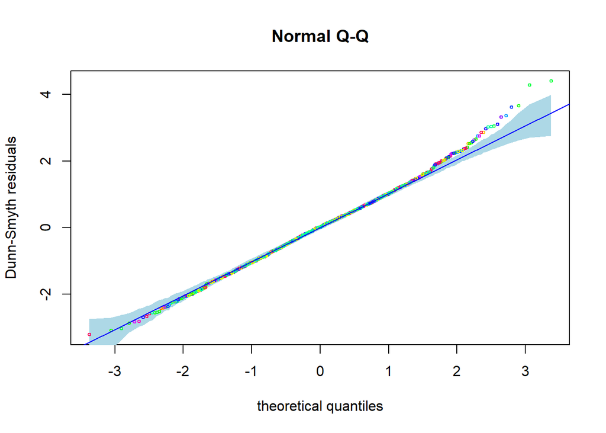

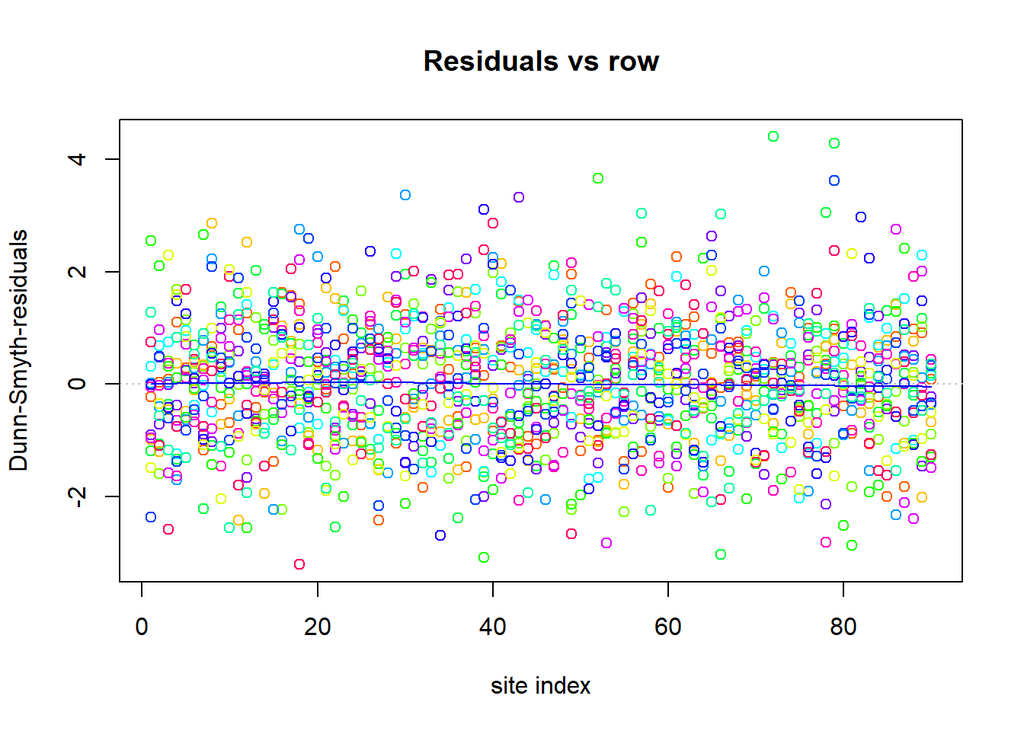

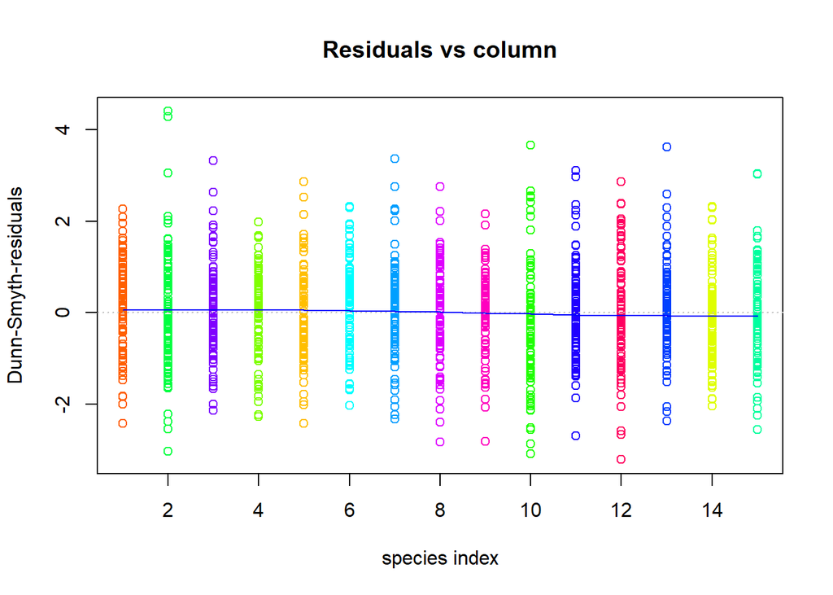

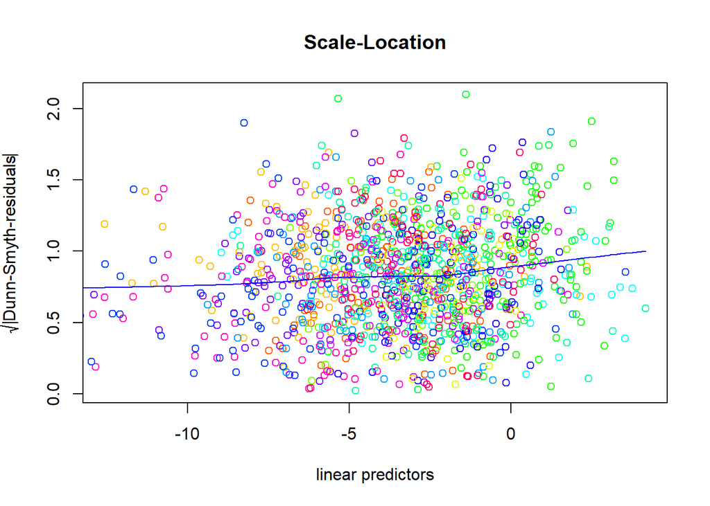

```r
# plot the residuals
plot(gllvm_carabid_pois, biplot = TRUE, ind.spp = TRUE)
```

```r
# no strong violation of homogeneity of variance.
```

Residuals seem okay for poisson model.

#### 7.3.2 Model outputs

Let’s plot the model coefficients

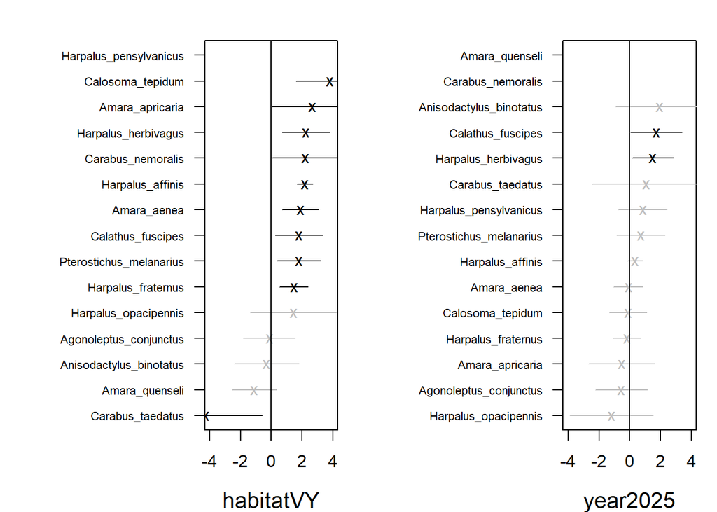

```r
# plot the gllvm carabid coefficient plot
coefplot(
  gllvm_carabid_pois,
  cex.ylab = 0.7,
  mar = c(4, 10, 2, 1),
  xlim.list = list(
    c(-4, 4),   # habitat
    c(-4, 4)    # year
  )
)
```

and then clean up the plot axis and save

```r
# clean up species names (remove underscore)
gllvm_carabid_pois_sc <- gllvm_carabid_pois

carabid_names_clean <- rownames(gllvm_carabid_pois_sc$params$Xcoef) |>
  str_replace_all("_", " ") |>
  str_to_sentence()

rownames(gllvm_carabid_pois_sc$params$Xcoef) <- carabid_names_clean
rownames(gllvm_carabid_pois_sc$sd$Xcoef)     <- carabid_names_clean

# open device to save plot using base R
png(
  filename = here::here("03_figures", "carabid_gllvm_plot.png"),
  width = 7,
  height = 6,
  units = "in",
  res = 400
)


# make italic
par(font.axis = 3)  # 3 = italic

# plot the gllvm carabid coefficient plot
coefplot(
  gllvm_carabid_pois_sc,
  cex.ylab = 0.7,
  mar = c(4, 10, 2, 1),
  xlim.list = list(
    c(-4, 4),   # habitat
    c(-4, 4)    # year
  )
)

# close device
dev.off()
```

Also make an ordination plot (latent variables as axis)

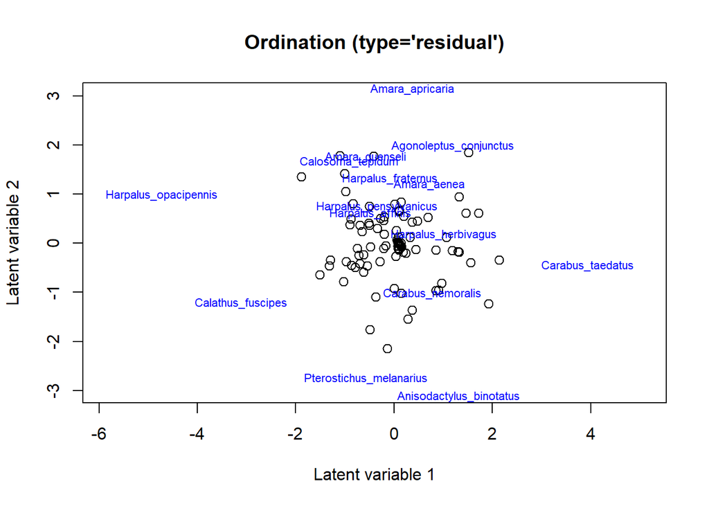

```r
ordiplot(gllvm_carabid_pois,
         biplot  = TRUE,
         ind.spp = 16,
         symbols = TRUE)
```

### 7.4 Carabid Fourth Corner Model

First we’ll prepare the trait data and make sure it lines up with the Y (response) dataframe. Again, we’ll only keep the carabid species with >5 individuals. Let’s also set the references as SNH, macropterous and native.

```r
# SPECIES TRAITS
# Ensure the species names in traits match the columns in Y
carabid_traits_rare_removed <- carabid_traits %>% filter(carabid_species %in% colnames(Y_rare_carabid_removed))

# ensure it's a dataframe in the same order as Y
carabid_traits_ordered <- carabid_traits_rare_removed[match(colnames(Y_rare_carabid_removed), carabid_traits_rare_removed$carabid_species), ]

# make spider_family the row names
rownames(carabid_traits_ordered) <- carabid_traits_ordered$carabid_species

# remove non-necessary columns
TR_carabid <- carabid_traits_ordered %>%
  dplyr::select(-carabid_species)     # remove non-trait columns

# Make sure it matches!
all(colnames(Y_rare_carabid_removed) %in% rownames(TR_carabid))
```

```
## [1] TRUE
```

```r
sum(colnames(Y_rare_carabid_removed) %in% rownames(TR_carabid))
```

```
## [1] 15
```

```r
# make sure reference levels make sense for model
X_carabid$habitat <- relevel(factor(X_carabid$habitat), ref = "SNH")

# set dispersal power reference level to macropterous
TR_carabid$dispersal_power <- relevel(
  factor(TR_carabid$dispersal_power),
  ref = "macropterous"
)

# set status to be introduced
TR_carabid$status <- relevel(
  factor(TR_carabid$status),
  ref = "native"
)
```

Now we’ll run the gllvm fourth corner model with the traits included.

```r
# run gllvm model
# Y is spider family matrix grouped by site/ habitat/ year
# X is predictor variables (habitat)
# TR is carabid traits
# offset for trap count, row effect for site ID
gllvm_carabid_traits <- gllvm(
  y = Y_rare_carabid_removed,
  X = as.data.frame(X_carabid),
  TR = TR_carabid,
  family = "negative.binomial",
  num.lv = 2,
  method = "VA",
  offset = off_vec,
  studyDesign = studyDesign,
  row.eff = ~(1 | site_ID),
  formula = y ~ habitat * (dispersal_power + status))

summary(gllvm_carabid_traits)
```

```
##
## Call:
## gllvm(y = Y_rare_carabid_removed, X = as.data.frame(X_carabid),
##     TR = TR_carabid, formula = y ~ habitat * (dispersal_power +
##         status), family = "negative.binomial", num.lv = 2, studyDesign = studyDesign,
##     row.eff = ~(1 | site_ID), offset = off_vec, method = "VA")
##
## Family:  negative.binomial
##
## AIC:  1954.64 AICc:  1962.187 BIC:  2313.983 LL:  -908.3 df:  69
##
## Informed LVs:  0
## Constrained LVs:  0
## Unconstrained LVs:  2
##
## Formula:  ~habitatVY+dispersal_powerbrachypterous+dispersal_powerdimorphic+dispersal_powerpolymorphic+statusintroduced+habitatVY:dispersal_powerbrachypterous+habitatVY:dispersal_powerdimorphic+habitatVY:dispersal_powerpolymorphic+habitatVY:statusintroduced
## LV formula:  ~ 0
## Row effect:  ~(1 | site_ID)
##
## Coefficients predictors:
##                                        Estimate Std. Error z value Pr(>|z|)
## habitatVY                                1.9164     0.3773   5.079 3.79e-07 ***
## dispersal_powerbrachypterous            -1.4347     0.3518  -4.079 4.53e-05 ***
## dispersal_powerdimorphic                -1.2390     0.1595  -7.766 8.09e-15 ***
## dispersal_powerpolymorphic              -1.7265     0.2819  -6.124 9.12e-10 ***
## statusintroduced                        -2.9395     0.1170 -25.120  < 2e-16 ***
## habitatVY:dispersal_powerbrachypterous  -2.1184     1.1476  -1.846  0.06490 .
## habitatVY:dispersal_powerdimorphic      -0.1510     0.4927  -0.306  0.75925
## habitatVY:dispersal_powerpolymorphic    -2.7569     0.9326  -2.956  0.00311 **
## habitatVY:statusintroduced               0.5320     0.4630   1.149  0.25056
## ---
## Signif. codes:  0 '***' 0.001 '**' 0.01 '*' 0.05 '.' 0.1 ' ' 1
```

#### 7.4.1 Meeting model assumptions

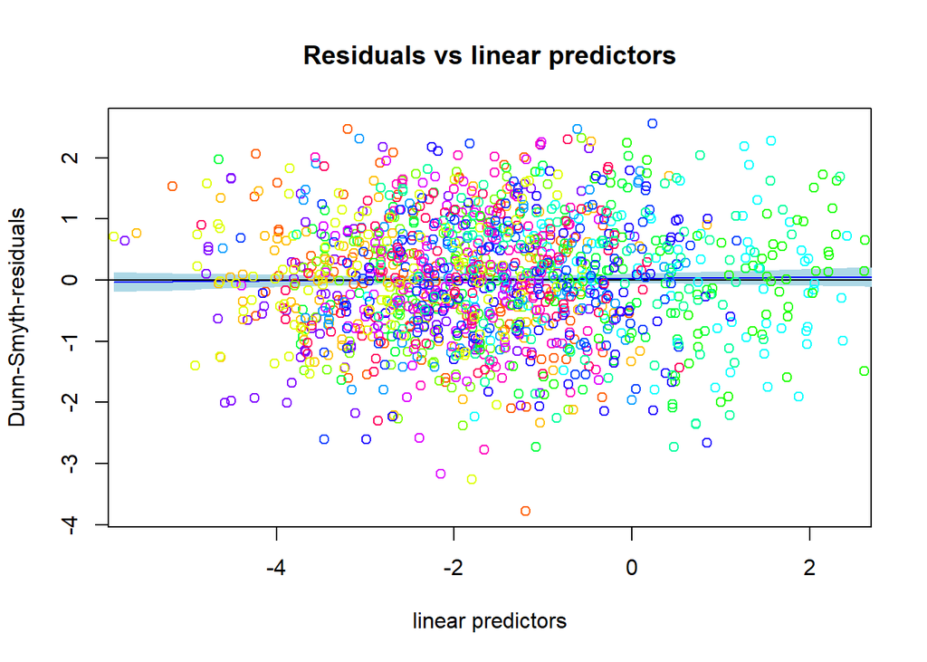

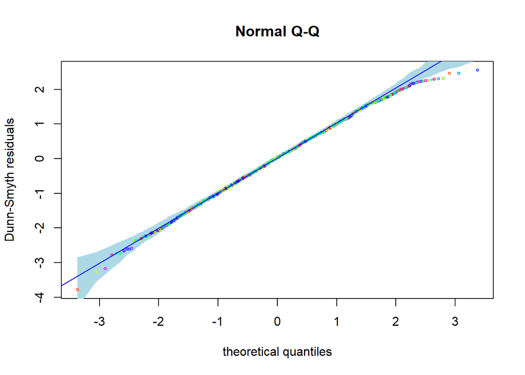

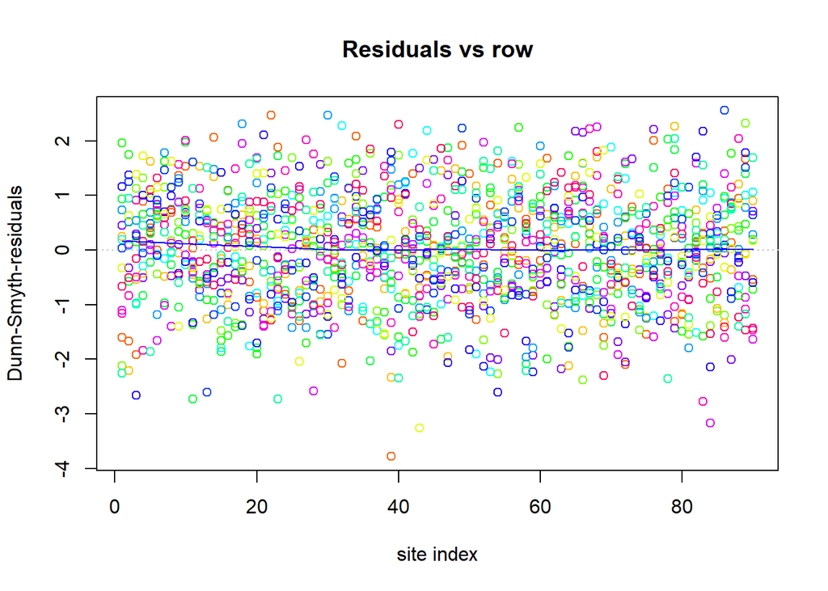

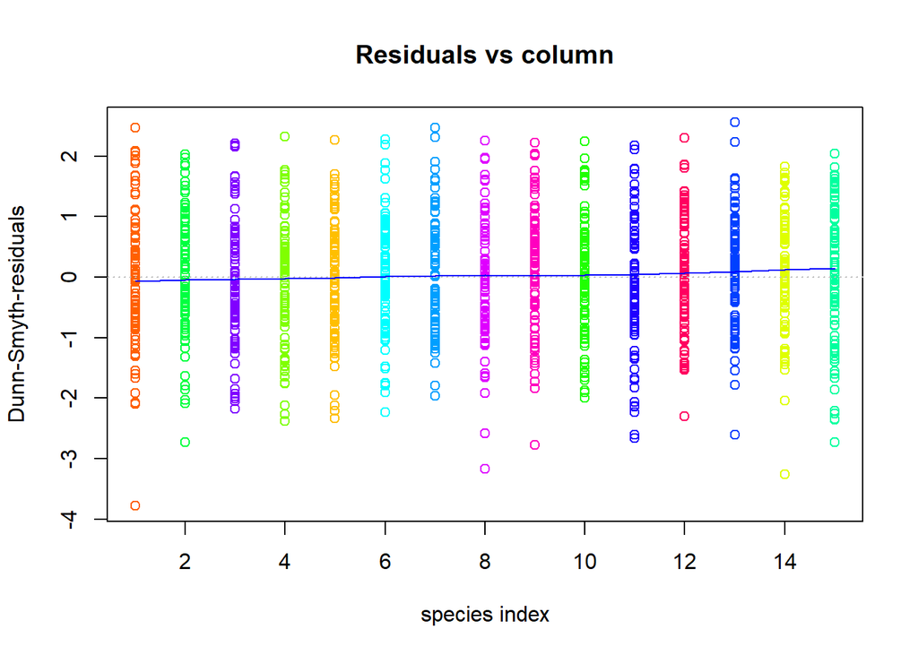

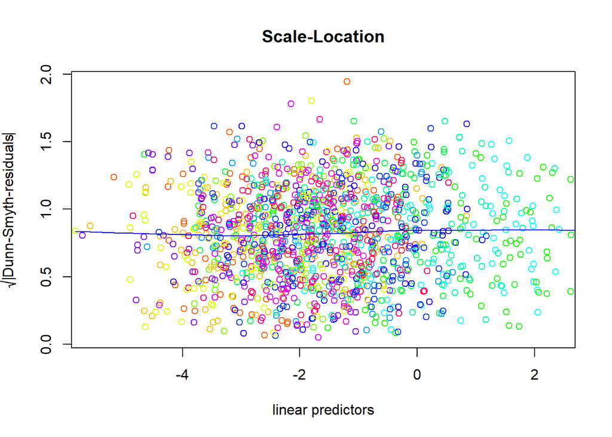

```r
# biplot of the GLLVM
plot(gllvm_carabid_traits, biplot = TRUE, ind.spp = TRUE)
```

residuals look okay!

#### 7.4.2 Model outputs

Plot and save fourth corner plot

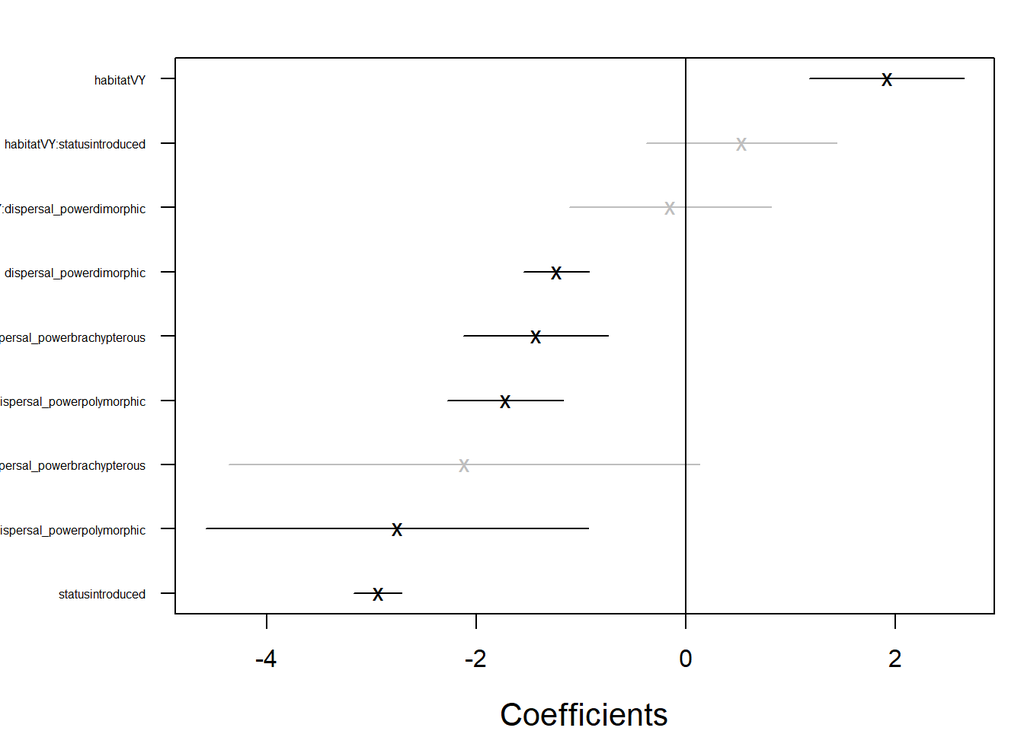

```r
coefplot(gllvm_carabid_traits)
```

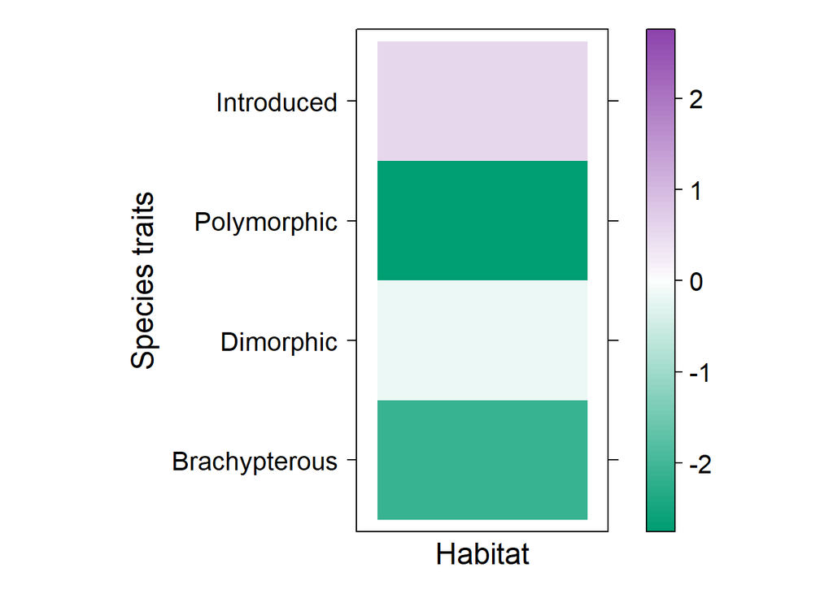

```r
carabid_fourth <- gllvm_carabid_traits$fourth.corner
a <- max( abs(carabid_fourth) )

# remove prefix (status/ dispersal power) for plotting
colnames(carabid_fourth) <- colnames(carabid_fourth) |>
  str_remove("^(status|dispersal_power)_?") |>  # remove either prefix
  str_replace("_", " / ")
colnames(carabid_fourth) <- colnames(carabid_fourth) |>
  str_to_sentence()


# add colors for habitats
colort <- colorRampPalette(c(
  custom_colors["SNH"],  # negative
  "white",
  custom_colors["VY"]    # positive
))


# plot fourth corner model using levelplot from lattice package
carabid_4th_plot <- levelplot(
  as.matrix(carabid_fourth),
  xlab = "Habitat",
  ylab = "Species traits",
  col.regions = colort(100),
  at = seq(-a, a, length = 100),
  scales = list(x = list(draw = FALSE)),
  par.settings = list(
    axis.text = list(cex = 1.3),
    par.xlab.text = list(cex = 1.5),
    par.ylab.text = list(cex = 1.5),
    par.legend.text = list(cex = 1.3)
  )
)

carabid_4th_plot
```

```r
# open device (save image using base R)
png(
  filename = here::here("03_figures", "carabid_4th_plot.png"),
  width = 7,
  height = 7,
  units = "in",
  res = 400
)

# draw the plot
print(carabid_4th_plot)

# close device
dev.off()
```

Polymorphic carabid beeltes associated with SNH.